# Multiple Linear Regressions (GLMs) - Solution

# **The Set-up**

## *Learning objectives.*

1. Explore your dataset to avoid common statistical problems when performing a simple/multiple linear regression.
2. Implement as simple/multiple linear regression in `R`.
3. Discriminate between raw and standardised regressions coefficients.
4. Determine the fit of a linear regression and establish how good a model is.
5. Reduce a model to the minimum adequate number of predictors using a stepwise procedure.

## *Before you start*

The practical will be run using *RStudio cloud* to avoid individual machine troubleshooting. This means you **need** to have an account for *RStudio cloud*.

However, remember to have [`R`](https://cran.r-project.org) and [R-studio](http://www.rstudio.com/) in your/room computer so you can work on the project after class.

**You should have also** 1. Read chapter 10 of Crawley the R book. 2. Done the Tutorial for this week.

## *The way it’s going to be run*

In this 3h practical you will to implement what you have learned in the class about Regression Analyses in `R`.

You will be building and **R-Markdown** document during the class. **R-Markdown** documents allows you to combine your code, its results, and your prose commentary into a single document. If you manage to produce a document your code works. The resulting file (a html) is what you will hand-in at the end of the practical.

This 3h practical is divided into seven parts (24 tasks in total). Also try to write your own `R`-code and run it **DO NOT COPY THE CODE OF SOMEONE ELSE**. Writing your code and figuring out why it does not work is the best way to understand the dynamics of the `R` language and the tasks you are doing. Also, you have an excellent teaching assistant resource - ask him and/or me all the questions you have.

The final document will have three classes of boxes

The text in the blue filled box marked as **Your task** states what you need to do

```r
#
# The code in the window marked like this shows where you need to write your code
#
```

The text in the green filled box marked as **Question** phrases a question, and where you will place the answer to the **question** is marked as ***PLACE YOUR ANSWER HERE**.

# **Environmental factors driving Denmark’s biodiversity patterns.**

## About the data you will use.

The data to be used in this week practical is a combination of the biodiversity data from the [Biowide](https://ecos.au.dk/forskningraadgivning/temasider/biowide) project, which aimed at collecting biodiversity data from 130 terrestrial sampling sites across Denmark. The dataset contains data for Plants (vascular plants and bryophytes), fungi (lichens and macrofungi), gastropods, and arthropods. You can get the [biodiversity data](https://www.gbif.org/dataset/cd4eb3ec-0a18-42b4-bda4-155716ddd7b1#description) from the Danish Biodiversity Information Facility. For further information on the project check the publication.

Although environmental variables were collected as part of Biowide, this data is not available for our use. The data on environmental variables included in the table you will use comes from multiple Geospatial datasets I complied for this course.

Here you will focus on the flowing variables:

**1) decimalLongitude**: East-West position in decimal-degrees of a sample site coming from [Biowide](https://ecos.au.dk/forskningraadgivning/temasider/biowide).

**2) decimalLatitude**: North-South position in decimal-degrees of a sample site coming from [Biowide](https://ecos.au.dk/forskningraadgivning/temasider/biowide).

**3) Log.S.AllGrp**: Logarithm of the total species richness of a sample site (sum of the unique species of all sampled groups in a site) coming from [Biowide](https://ecos.au.dk/forskningraadgivning/temasider/biowide).

**4) landsdele**: Regional political unit of Denmark coming form the Database of Global Administrative Areas [GADAM](https://gadm.org).

**5) Geology**: Geological formation coming from the [Denamrk’s geological service](https://eng.geus.dk/products-services-facilities/data-and-maps/maps-of-denmark).

**6) NatDensBasMp**: Density of natural land cover types as defined by [BASEMAP](https://envs.au.dk/en/research-areas/society-environment-and-resources/land-use-and-gis/basemap).

**7) Dis2Cost**: Distance in km of a sampled site to the coast estimated by me using Denmark high resolution contour map coming form the Database of Global Administrative Areas [GADAM](https://gadm.org).

**8) HII**: [Human Influence Index](https://sedac.ciesin.columbia.edu/data/set/wildareas-v2-human-influence-index-geographic), a measurement of the anthropogenic impacts on the environment.

**9) Slope30mAgg**: the maximum rate of change in value from that cell to its neighbours estimated based on the [SRTM-30m DEM](https://www2.jpl.nasa.gov/srtm/).

**10) PrecSea**: Seasonality of precipitation measured as the variability of monthly values (using the CV) coming the [CHELSA-climatologies](https://chelsa-climate.org) .

## 1. Load the Data

**Your task:** Load the data in *Biowide_AllSppRich.csv*, located in the files of the project

Use `read.csv` to load the file - The file is comma-separated

Save the object as an object named `DK.Biodiv`.

```r
# Read the file and save it as an object named `DK.Biodiv`
DK.Biodiv <-  read.csv("Data/Biowide_AllSppRich.csv")
```

## 2. Data Exploration: oultiers in X and Y

**Your task:**

Using the object `DK.Biodiv`, you will now build a box plot for each continuous predictor variables adding a “title” to each plot using the `main` argument.

To be clear the response variable is *Richness of all sampled species* [`Log.S.AllGrp`].

The predictors are: 1) *Region* [`landsdele`] 2) *Parental material* [`Geology`] 3) *Nature Density* [`NatDensBasMp`] 4) *Distance to coast* [`Dis2Cost`] 5) *Human Impact Index* [`HII`] 6) *Slope* [`Slope30mAgg`] 7) *Precipitation Seasonality* [`PrecSea`]

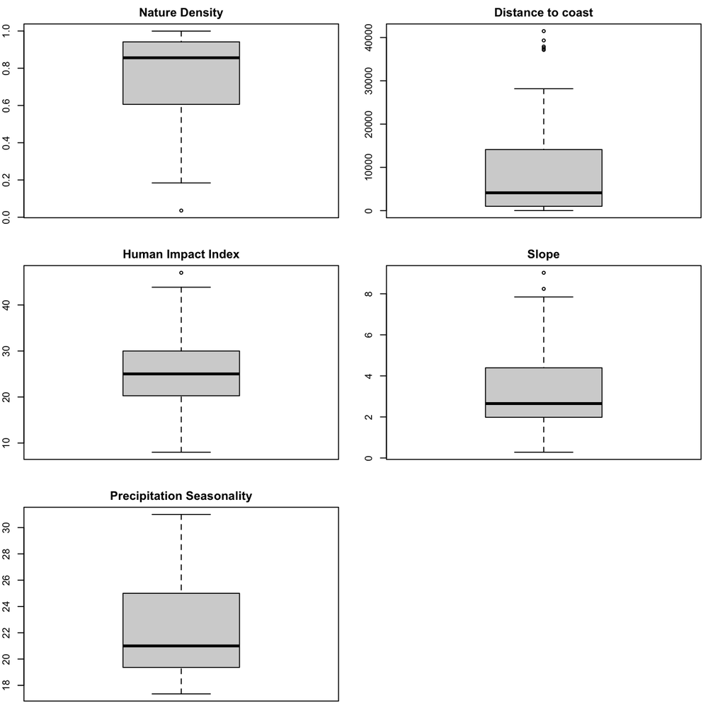

```r
# Set a plotting space with 6 regions (two columns and three rows). For this, use the function par()
par(mfrow = c(3,2),mar=rep(2,4))

# Plot a box-plot for Nature Density
boxplot(DK.Biodiv$NatDensBasMp,
        main = "Nature Density")
# Plot a box-plot for Distance to coast
boxplot(DK.Biodiv$Dis2Cost,
        main = "Distance to coast")
# Plot a box-plot for Human Impact Index
boxplot(DK.Biodiv$HII,
        main = "Human Impact Index")
# Plot a box-plot for Slope
boxplot(DK.Biodiv$Slope30mAgg,
        main = "Slope")
# Plot a box-plot for Precipitation Seasonality
boxplot(DK.Biodiv$PrecSea,
        main = "Precipitation Seasonality")
```

**Question**: For which variable can you detect outlier observation.

# Data Exploration: Is there homogeneity of variances - 1?

**Your task:**

Here you will evaluate if the variance in the richness of all sampled species in the **Biowide** project are homogeneous across all predictors. **Remember that the response variable here is `Log.S.AllGrp`**.

For this, you will assess this assumption for each of the five predictors plus Latitude and longitude **individually**.

You should use a `for()` loop to determine homoscedasticity of Log-species richness across predictors.

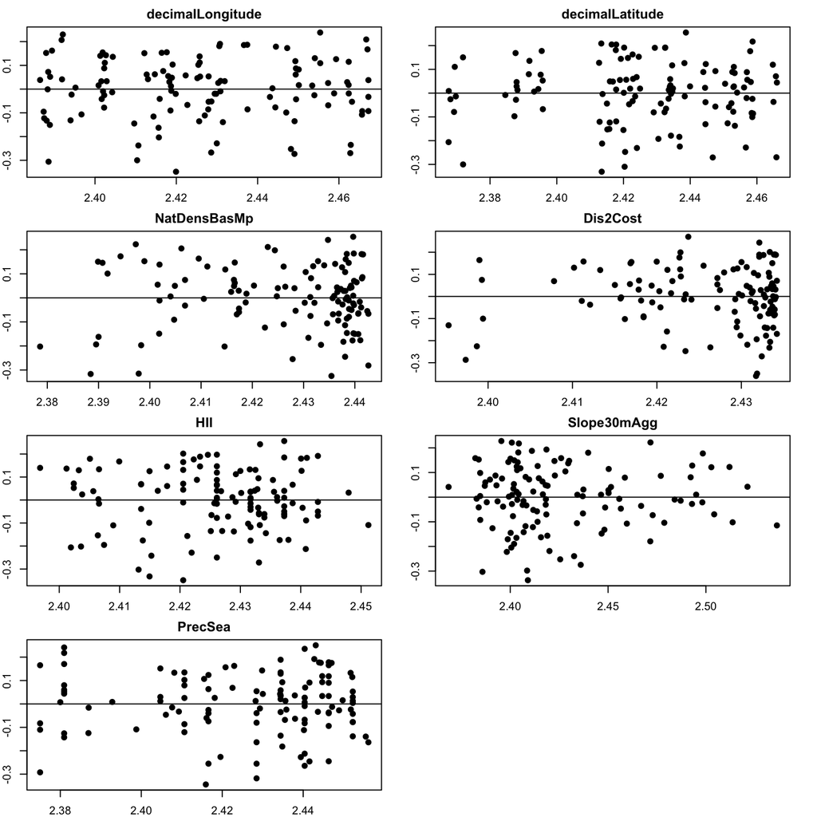

```r
# Build 4x3 plotting space filled row-wise
par(mfrow = c(4,2),
    mar = rep(2,4))

# Create a Vector named PredNames with the predictors names
PredNames <- names(DK.Biodiv)[-c(1,4:6)]

# Loop using i as an iterator and cycle through PredNames
for (i in PredNames){
# Create a new subset data.frame named DK.Div.Tmp that only contains ONLY the log-richness and the evaluated predictors as variables
  DK.Div.Tmp <- DK.Biodiv[,c("Log.S.AllGrp",i)]

# Build a regression model, using the lm() function, and store it as an object named Lm.Mod
  Lm.Mod <- lm(Log.S.AllGrp ~ .,
               data = DK.Div.Tmp)

# Save the residuals into an object named Lm.Resid
  Lm.Resid <- residuals(Lm.Mod)

# Save the fitted/predicted values into an object named Lm.Fitt
  Lm.Fitt <- predict(Lm.Mod)

  # Plot the Residuals vs Predicted values
  plot(Lm.Resid ~ Lm.Fitt,
       pch=19, # This argument as defined sets the plotting point to a filled dot.
       xlab = "Fitted values", # This argument define the text to be added as the x-axis label
       ylab = "Residuals", # This argument define the text to be added as the y-axis label
       main = i) # This argument define the text to be added figure title
# Add a horizontal line using the abline() function at zero for reference
  abline(h=0)
}
```

**Question:** Is the variance of log-richness for all sampled species homoscedastic for individual variables?

Distance to coast, and Slope show a funnel shape

# Data Exploration: Is there homogeneity of variances - 2?

**Your task:**

Now you will evaluate the variance in the log-richness for all sampled species is homogeneous across all predictors **simultaneously**.

For this, you will build a multiple regression where all seven(7) continuous predictors are combined into a single additive model **with no interactions**.

**Remember that your response variable is `Log.S.AllGrp`**.

```r
# Build a regression model using the lm() function where all six variables predict the log-richness for all sampled species. # save the model as an object named FullMod
FullMod <- lm(Log.S.AllGrp ~ NatDensBasMp + Dis2Cost + HII + Slope30mAgg + PrecSea + decimalLongitude + decimalLatitude,
              data = DK.Biodiv)
# Call the model
FullMod
```

```
##
## Call:
## lm(formula = Log.S.AllGrp ~ NatDensBasMp + Dis2Cost + HII + Slope30mAgg +
##     PrecSea + decimalLongitude + decimalLatitude, data = DK.Biodiv)
##
## Coefficients:
##      (Intercept)      NatDensBasMp          Dis2Cost               HII
##        4.383e+00         7.393e-02        -1.325e-06        -6.442e-04
##      Slope30mAgg           PrecSea  decimalLongitude   decimalLatitude
##        1.724e-02         2.124e-04         4.477e-03        -3.740e-02
```

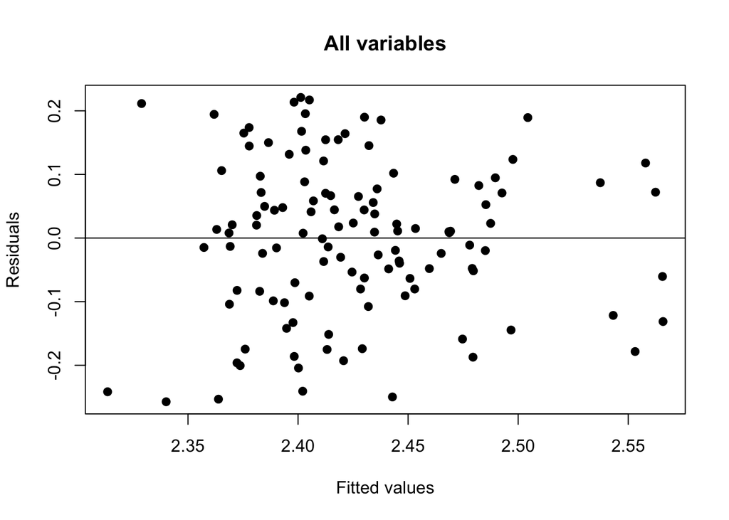

```r
# Now extract the residuals and save them into an object named Lm.Resid. For this, use the residuals() function
Lm.Resid <- residuals(FullMod)

# Now extract the fitted values and save them into an object named Lm.Fitt.  For this, use the predict() function
Lm.Fitt <- predict(FullMod)

# Plot the Residuals vs Predicted values
  plot(Lm.Resid ~ Lm.Fitt,
       pch=19, # This argument, as defined, sets the plotting point to a filled dot.
       xlab = "Fitted values", # This argument defines the text to be added as the x-axis label
       ylab = "Residuals", # This argument define the text to be added as the y-axis label
       main = "All variables", # This argument define the text to be added figure title
      ylim = range(Lm.Resid))
# Add a horizontal line using the abline() function at zero for reference
  abline(h = 0)
```

**Question:** Is the variance of log-richness for all sampled species homoscedastic?

The residual variation appears to be similar across all levels of fitted values (the spread does not show clear trends - but there are empty areas.

# Data Exploration: Are the residuals normally distributed?

**Your task:**

Using a simple multivariate additive model (that is and additive combination of the used predictors) build in the section above (that is the `Lm.Resid` object), you will now assess if the residuals are normally distributed. For this, you will:

- Generate a histogram (using the `hist()` function) of the **frequency** of the residuals from the simple multivariate additive model.

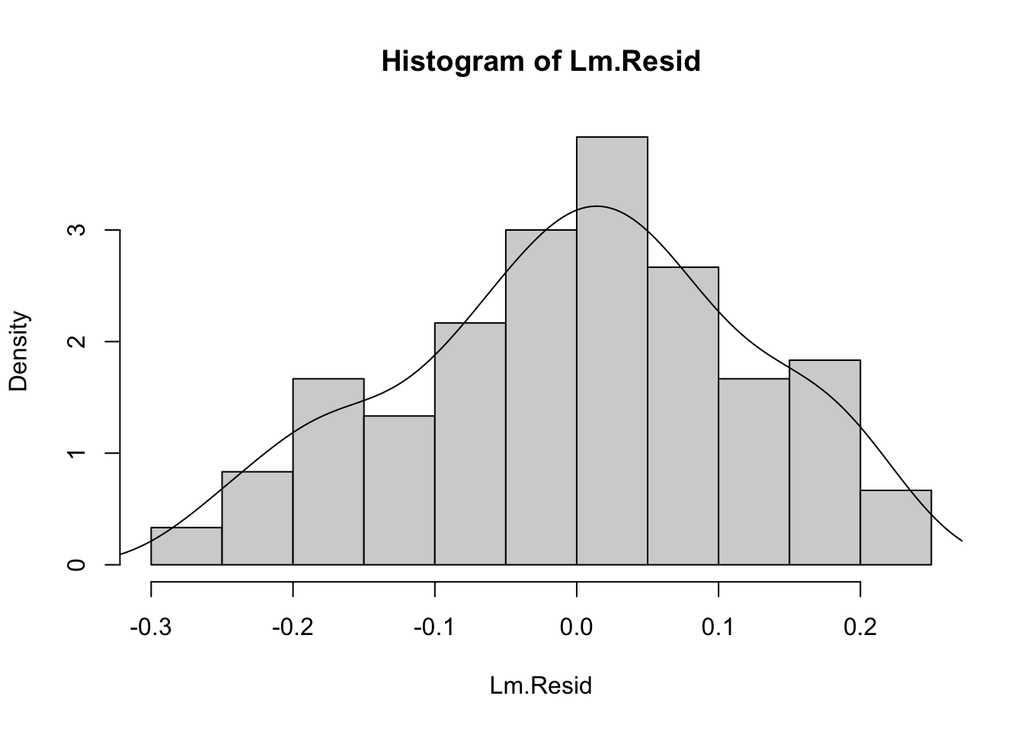

```r
# Use the hist() function to display the distribution of the residuals. Here do not plot the count but the frequency.
hist(Lm.Resid,
     freq = F)

# Estimate the density of the residuals using the function `density()`
Den.Lm.Resid <- density(Lm.Resid)

# Plot the density plot over the histogram

lines(Den.Lm.Resid)
```

```r
#
```

**Question:** Based on this histogram, is the residual variation normally distributed?**

The histogram would appear to be normal

**Your task:** Using a simple multivariate additive model (that is and additive combination of the used predictors) build in the section above (that is the `Lm.Resid` object), you will now assess if the residuals are normally distributed. For this, you will:

- Plot a q-q plot of the residuals, using the `qqnorm()` and `qqline()` functions.

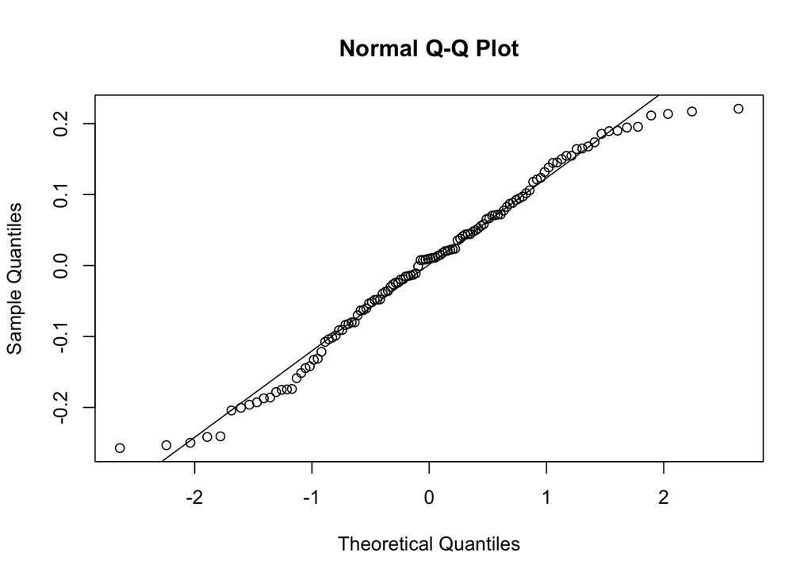

```r
# use the qqnorm() and qqline() functions to plot a qqplot
qqnorm(Lm.Resid) # use the qqnorm() on the object containing the residuals to make a q-q plot
qqline(Lm.Resid) # use the qqline in the object containing the residuals to add the expectation line
```

**Question:** Based on the q-q plot, is the residual variation normally distributed?

Although there is variability in the high end of the theoretical-observed trend, the residuals appear normally distributed

**Your task:**

Using a simple multivariate additive model (that is and additive combination of the used predictors) build in the section above (that is the `Lm.Resid` object), you will now assess if the residuals are normally distributed. For this, you will:

- Use the Shapiro–Wilk test (executed using the `shapiro.test()` function) to assess the normality of the residuals.

```r
# Implement the shapiro.test() function to assess normality of the residuals. Remember that a non-significant test (p>0.05) means that the observed and expected distribution (in this case, normal) are the same.
shapiro.test(Lm.Resid)
```

```
##
##  Shapiro-Wilk normality test
##
## data:  Lm.Resid
## W = 0.97917, p-value = 0.0596
```

**Question**: Based on this Shapiro–Wilk test, is the residual variation normally distributed?

The residual variation is just normally distributed because the p-value (0.0596) is larger than 0.05.

# Data Exploration: Is there collinearity among the covariates?

**Your task:**

Estimate the tolerance and VIF for all six predictors in the `DK.Biodiv` object. Use a Loop to estimate the tolerances for all variables.

```r
# Create a vector with only NA values named Tol.Summ to store the tolerance values
Tol.Summ <- rep(x = NA,
                times = length(PredNames))
# give names to each place in the vector using PredNames
names(Tol.Summ) <- PredNames

# Use a for loop across predictors (remember the names are in PredNames) to estimate the tolerance.
for (i in PredNames){
# Create new data.frame named Tol.DF was the first variable tested.
  Tol.DF <- data.frame(Pred = DK.Biodiv[,i], # the data of the predictor variable being tested should be included here  - call it using the i iterator.
                       DK.Biodiv[,PredNames[!PredNames%in%i]])# Add the other predictor variables here. For this, use the logical test !PredNames%in%i (each select all predictors variable EXECEPT i).

  # Build an lm model to predict the predictor of interest as a function of all other predictors. Save this model as Tol.LM.
    Tol.LM <- lm(Pred~.,
                 data = Tol.DF)
# To estimate the tolerance for the predictor of interest, the first step is to extract the R2 from the regression model and store it as an object name Tol.R2
    Tol.R2 <- summary(Tol.LM)$r.squared #

# estimate the tolerance (1-R2) and save it in the corresponding position of the Tol.Summ you created before the loop.
    Tol.Summ[i] <- 1 - Tol.R2
}

# now Call the vector Tol.Summ you created before the loop
Tol.Summ
```

```
## decimalLongitude  decimalLatitude     NatDensBasMp         Dis2Cost
##        0.3951572        0.8030244        0.7786716        0.8788889
##              HII      Slope30mAgg          PrecSea
##        0.8016830        0.7038345        0.3339619
```

**Question:** Which variable should be removed due to high collinearity variable?

While `PrecSea` is the most collinear variable with a tolerance value of 0.33 (VIF = 2.9), based on the normally used tolerance threshold of < 0.1, there is no collinearity.

# Data Exploration: What are the relationships between `Y` and `X` variables?

**Your task:**

Make multi-panel scatter-plots showing the relation between log-richness for all sampled species and each predictors.

For each panel add the regression line (using the `abline()` function) and the Pearson correlation coefficient (using the `legend()` function).

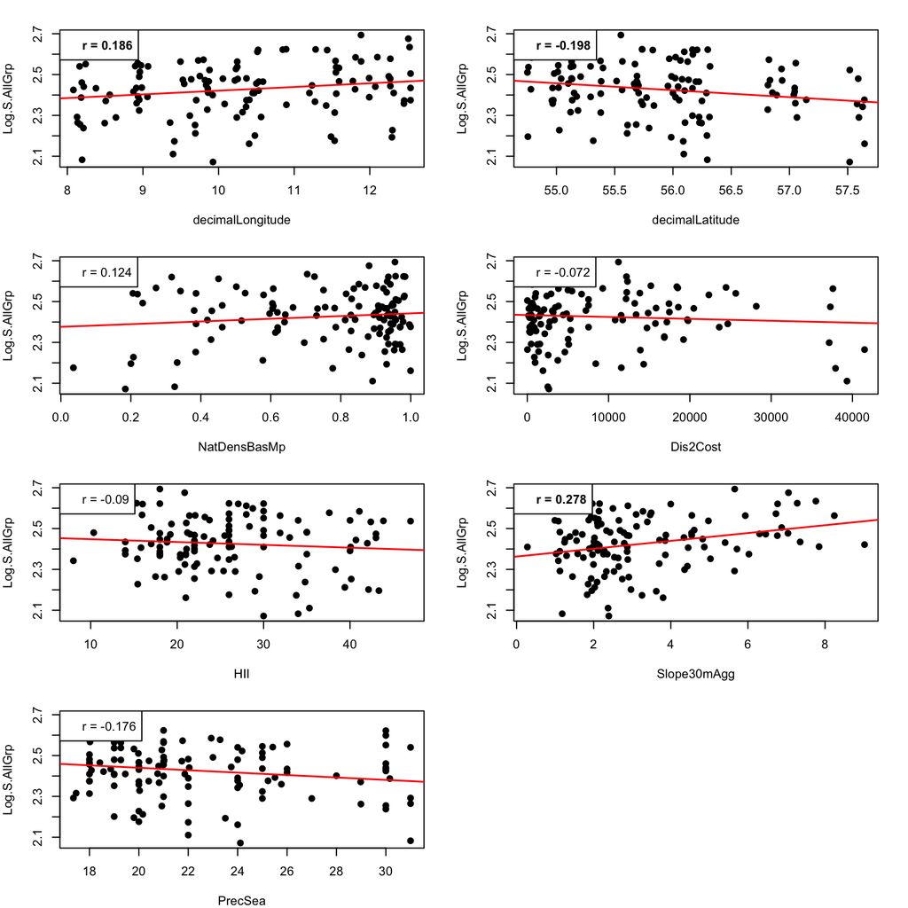

```r
# Build 3x2 plotting space filled row-wise
par(mfrow = c(4,2),
    mar=c(4,4,2,2))

# Now lets loop across predictors to estimate the Tolerance.
for (i in PredNames){

  # Subset DK.Biodiv to create a new data.frame named Temp.DF that has Log.S.AllGrp and the predictor evaluated
  Temp.DF <- DK.Biodiv[,c(i,"Log.S.AllGrp")]

  # Plot the bivariate relation
  plot(x = Temp.DF[,i], # Call the predictor
       y = Temp.DF$Log.S.AllGrp, # Call the response (Log.S.AllGrp)
       pch = 19, # Set the points to a filled dot
       xlab = i, # Set the Name for the X-axis
       ylab = "Log.S.AllGrp") # Set the Name for the Y-axis


# Add the regression line - using the abline function
# First create a regression object named Reg.Temp that has the regression between Log.S.AllGrp and the predictor
Reg.Temp <- lm(DK.Biodiv[,"Log.S.AllGrp"] ~ DK.Biodiv[,i])

# Using the abline function plot the object with the regression object
abline(Reg.Temp, # The regression object
       col="red", # Set the line colour to "red"
       lwd=1.5) # make the plotted line thicker

# Add the the Pearson correlation - make the text boldface if the relation is significant
legend("topleft",
       legend = paste0("r = ",
                       round(cor(na.omit(Temp.DF))[2,1],3)
                       ),
       text.font = ifelse(cor.test(na.omit(Temp.DF)[,1],na.omit(Temp.DF)[,2])$p.value<0.05,2,1))
}
```

**Question:** Which variables show a relation with Log.S.AllGrp?

# Data Exploration: Are observations of the response variable independent?

**Your task:** Now you will evaluate if the independence of the Observations. For this, plot the residuals (`Lm.Resid`) vs. the response variable (`Log.S.AllGrp`).

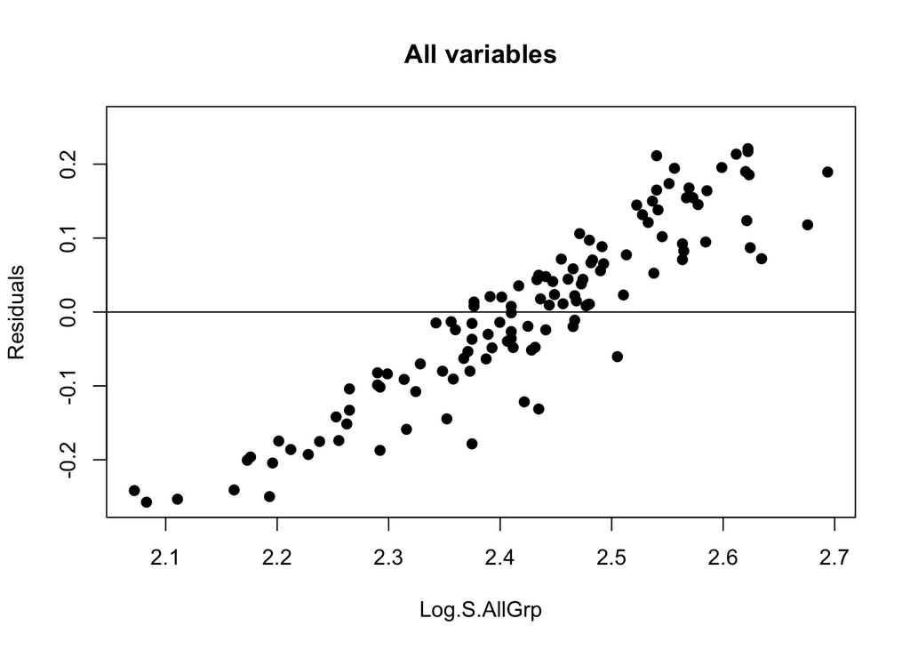

```r
# Plot the Residuals vs response variable
  plot(Lm.Resid ~ Log.S.AllGrp,
       data = DK.Biodiv[as.numeric(names(Lm.Resid)),],
       pch=19, # This argument, as defined, sets the plotting point to a filled dot.
       xlab = "Log.S.AllGrp", # This argument defines the text to be added as the x-axis label
       ylab = "Residuals", # This argument define the text to be added as the y-axis label
       main = "All variables", # This argument define the text to be added figure title
      ylim = c(-max(abs(Lm.Resid)), # a new argument you will use here is ylim to set the lower and upper limits of the y-axes. For this, you will specify a vector of two-element with the lower and upper limits. This will allow you to make the y-axis symmetric.
               max(abs(Lm.Resid))))
# Add a horizontal line using the abline() function at zero for reference
  abline(h=0)
```

**Question:** Do you see any patterns in the residuals?

There is CLEAR a consistent upward trend in the residuals. This means the observations are not independent of each other - something you can expect if you consider that this is spatial data

# Multiple Linear Regressions - first implementation

**Your task:** You have a regression object (`FullMod`). Plot the regression object to see what is shown.

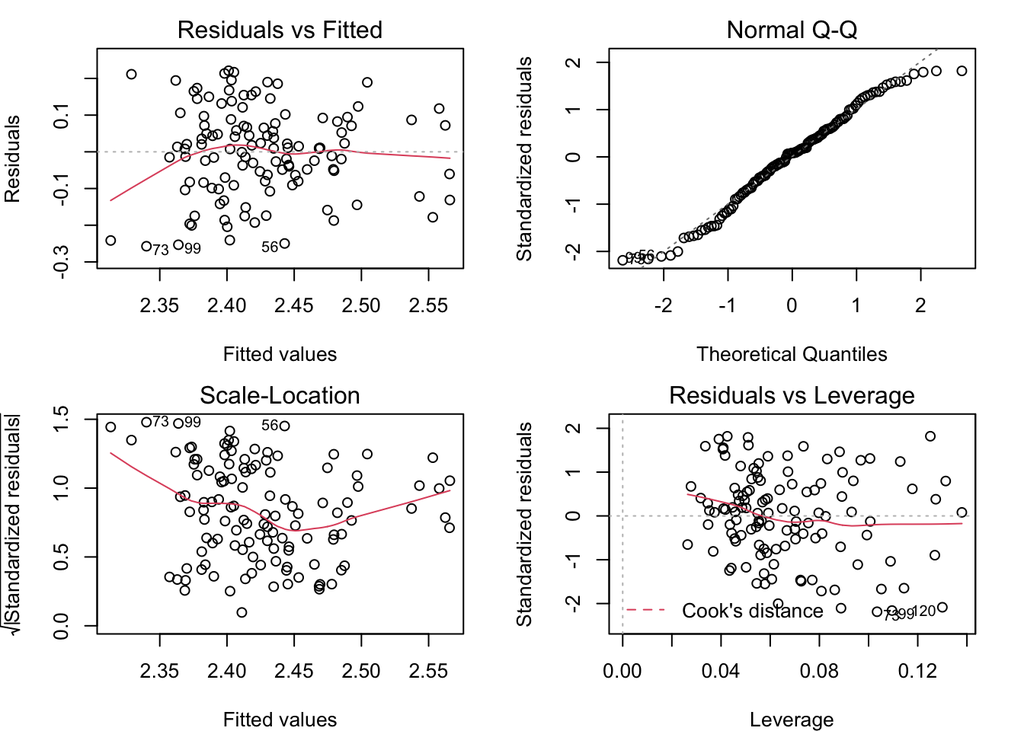

```r
# Build 2x2 plotting space filled row-wise
par(mfrow = c(2,2), # you need to specify two values here the number of rows and the number of columns
    mar=c(4,4,2,2)) # here you define the 'margins" - blank space between plotting areas)
# use the plot function on the lm object named FullMod
plot(FullMod)
```